# Delvinne & de Graaff, RCrk Data Overview

```r
library(dplyr)
library(tidyverse)
library(ggplot2)
library(knitr)
library(DT)
library(gridExtra)
library(grid)
library(readxl)
library(leaflet)
library(viridis)
library(reshape)

options(ggplot2.continuous.colour="viridis")
options(ggplot2.continuous.fill = "viridis")
options(width = 100)

### Data folder
data_path <- "C:/Users/derek/Google Drive/RCrk/RC data from Marie Anne/"
```

```r
#function for converting RC UTM locs to decimal degree
library(rgdal)
#utm <- utm[complete.cases(utm),]
#utm1 <- data.frame(x=utm$Northing,y=utm$Easting)

UTM_to_DD <- function(east, north) {
  df <- data.frame(x=east, y=north)
  coordinates(df) <- ~x+y
  class(df)
  suppressWarnings(
    proj4string(df) <- CRS("+proj=utm +zone=11 +datum=WGS84 +units=m +ellps=WGS84")
  )
  suppressWarnings(
  proj4string(df) <- CRS("+proj=utm +zone=11 +datum=WGS84 +units=m +ellps=WGS84")
  )
  df2 <- spTransform(df,CRS("+proj=longlat +datum=WGS84"))
  return(coordinates(df2))
}
```

```r
#rmd mapping fix
# local({
#
#   # The directory where Pandoc will be extracted. Feel free
#   # to adjust this path as appropriate.
#   dir <- "~/rstudio-pandoc"
#
#   # The version of Pandoc to be installed.
#   version <- "2.7.1"
#
#   # Create and move to the requested directory.
#   dir.create(dir, showWarnings = FALSE, recursive = TRUE)
#   owd <- setwd(dir)
#   on.exit(setwd(owd), add = TRUE)
#
#   # Construct path to pandoc.
#   root <- "https://s3.amazonaws.com/rstudio-buildtools"
#   suffix <- sprintf("pandoc-%s-windows-x86_64.zip", version)
#   url <- file.path(root, "pandoc-rstudio", version, suffix)
#
#   # Download and extract pandoc.
#   file <- basename(url)
#   utils::download.file(url, destfile = file)
#   utils::unzip(file)
#   unlink(file)
#
#   # Write .Renviron to update the version of Pandoc used.
#   entry <- paste("RSTUDIO_PANDOC", shQuote(path.expand(dir)), sep = " = ")
#   contents <- if (file.exists("~/.Renviron")) readLines("~/.Renviron")
#   filtered <- grep("^RSTUDIO_PANDOC", contents, value = TRUE, invert = TRUE)
#   amended <- union(filtered, entry)
#   writeLines(amended, "~/.Renviron")
#
#   # Report change to the user.
#   writeLines("Updated .Renviron:\n")
#   writeLines(amended)
#   writeLines("\nPlease restart RStudio for these changes to take effect.")
#
# })
```

```r
#create basemap
#Bring in RC boundary
rc_watersheds <- readOGR("C:/github/RC-som-shiny/prototype/RCproto/map/watersheds_2014.shp", layer="watersheds_2014")
rc_watersheds <- spTransform(rc_watersheds, CRS("+proj=longlat +datum=WGS84 +no_defs"))

my_map <- leaflet() %>%
        addProviderTiles(
        "Esri.WorldTopoMap",
        # give the layer a name
        group = "Esri.WorldTopoMap"
      ) %>%
        addProviderTiles(
        "OpenStreetMap",
        # give the layer a name
        group = "OpenStreetMap"
      ) %>%
        addProviderTiles(
          "Stamen.Toner",
          group = "Stamen.Toner"
        ) %>%
        addProviderTiles(
          "Stamen.Terrain",
          group = "Stamen.Terrain"
        ) %>%
        addProviderTiles(
          "Esri.WorldStreetMap",
          group = "Esri.WorldStreetMap"
        ) %>%
        addProviderTiles(
          "Wikimedia",
          group = "Wikimedia"
        ) %>%
        addProviderTiles(
          "CartoDB.Positron",
          group = "CartoDB.Positron"
        ) %>%
        addProviderTiles(
          "Esri.WorldImagery",
          group = "Esri.WorldImagery"
        ) %>%
      # add a layers control
      addLayersControl(
        baseGroups = c(
          "Esri.WorldTopoMap", "OpenStreetMap", "Stamen.Toner","Stamen.Terrain", "Esri.WorldStreetMap",
          "Wikimedia", "CartoDB.Positron", "Esri.WorldImagery"
        ),
        # position it on the topleft
        position = "topleft"
      )  %>%
        addPolygons(data=rc_watersheds,
                  col = 'black',
                  stroke = TRUE,
                  weight=2,
                  opacity=1,
                  fillColor="grey90",
                  fillOpacity = 0.05,
                  smoothFactor = 2)
```

### Overview

#### Project includes 6 datasets that cover 4 sites spread across the Reynolds Creek elevation gradient

*Datasets:*

1. Soil CN (already in SoDaH)
2. Soil respiration
3. Soil size fractions (0-5 cm)
4. Litterfall: leaf and stock mass
5. Litter CN
6. Microbial composition (bacteria:fungi)

### 1. Site map & soil CN

```r
soilCN <- as.data.frame(read_excel(paste0(data_path,"soil C and N.xlsx"), sheet = "data"))

#rename CN columns
names(soilCN)[names(soilCN) == 'Sample ID'] <- 'SampleID'
names(soilCN)[names(soilCN) == '%C'] <- 'Cperc'
names(soilCN)[names(soilCN) == '%N'] <- 'Nperc'

#convert coordinates to decimal degrees
dd_coords <- as.data.frame(UTM_to_DD(soilCN$X_Easting, soilCN$Y_Northing))
soilCN$lat <- dd_coords$y
soilCN$long <- dd_coords$x

#rearrange the dataframe
soilCN <- soilCN %>% select(SampleID, Location, Elevation,
                  X_Easting, Y_Northing, lat, long,
                  Cperc, Nperc)

#fix obvious bad data
soilCN$Nperc[soilCN$Nperc < 0.001] <- NA
soilCN$CN <- ifelse(soilCN$Nperc > 0.001, soilCN$Cperc/soilCN$Nperc, NA)

#preview data columns
str(soilCN)
```

```
## 'data.frame':    153 obs. of  10 variables:
##  $ SampleID  : chr  "F1Ca" "F1Cb" "F1Cc" "F1Cd" ...
##  $ Location  : chr  "Flats" "Flats" "Flats" "Flats" ...
##  $ Elevation : num  1188 1188 1188 1188 1188 ...
##  $ X_Easting : num  521389 521389 521389 521389 521389 ...
##  $ Y_Northing: num  4786220 4786220 4786220 4786220 4786220 ...
##  $ lat       : num  43.2 43.2 43.2 43.2 43.2 ...
##  $ long      : num  -117 -117 -117 -117 -117 ...
##  $ Cperc     : num  1.103 0.545 0.572 0.71 0.835 ...
##  $ Nperc     : num  0.1194 0.0593 0.0586 0.0684 0.096 ...
##  $ CN        : num  9.24 9.19 9.76 10.39 8.7 ...
```

```r
##map data points
my_map %>% addCircleMarkers(lat=soilCN$lat, lng=soilCN$long,
             popup=soilCN$Cperc,
             #color = ~Cperc,   #<<< HOW TO FIX TO SHOW COLOR SCALE???
             stroke = FALSE,
             fillOpacity = 0.5,
             radius=5)
```

[interactive chart not shown]

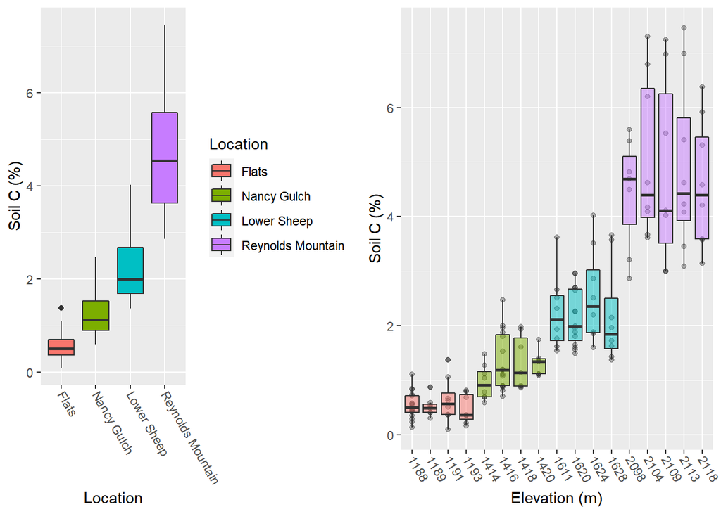

```r
## Plot C data
soilCN$Location <- factor(soilCN$Location , levels=c("Flats", "Nancy Gulch", "Lower Sheep", "Reynolds Mountain"))
C_by_loc <- ggplot(soilCN, aes(x=Location, y=Cperc, fill=Location)) + geom_boxplot() +
  xlab("Location") + ylab("Soil C (%)") +
  theme(axis.text.x = element_text(angle = -60, vjust = 0.5, hjust=0))

#boxplot by elevation
C_by_elv <- ggplot(soilCN, aes(x=as.character(round(Elevation,0)), y=Cperc, fill=Location)) + geom_point(alpha=0.3) + geom_boxplot(alpha=0.5) +
  theme(axis.text.x = element_text(angle = -60, vjust = 0.5, hjust=0)) +
  xlab ("Elevation (m)") + ylab("Soil C (%)") + theme(legend.position = "none")

grid.arrange(C_by_loc, C_by_elv, ncol=2)
```

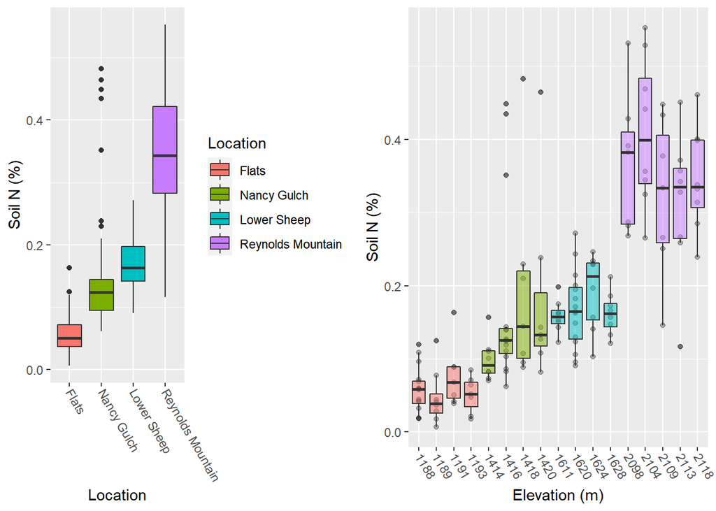

```r
## Plot N data
N_by_loc <- ggplot(soilCN, aes(x=Location, y=Nperc, fill=Location)) + geom_boxplot() +
  xlab("Location") + ylab("Soil N (%)") +
  theme(axis.text.x = element_text(angle = -60, vjust = 0.5, hjust=0))

#boxplot by elevation
N_by_elv <- ggplot(soilCN, aes(x=as.character(round(Elevation,0)), y=Nperc, fill=Location)) + geom_point(alpha=0.3) + geom_boxplot(alpha=0.5) +
  theme(axis.text.x = element_text(angle = -60, vjust = 0.5, hjust=0)) +
  xlab ("Elevation (m)") + ylab("Soil N (%)") + theme(legend.position = "none")

grid.arrange(N_by_loc, N_by_elv, ncol=2)
```

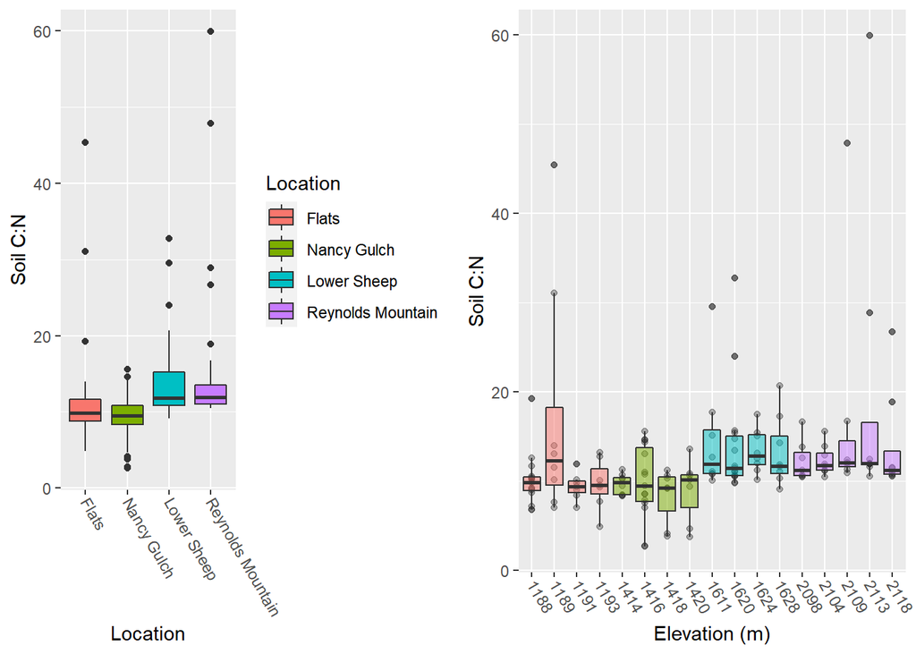

```r
## Plot CN data
CN_by_loc <- ggplot(soilCN, aes(x=Location, y=CN, fill=Location)) + geom_boxplot() +
  xlab("Location") + ylab("Soil C:N") +
  theme(axis.text.x = element_text(angle = -60, vjust = 0.5, hjust=0))

#boxplot by elevation
CN_by_elv <- ggplot(soilCN, aes(x=as.character(round(Elevation,0)), y=CN, fill=Location)) + geom_point(alpha=0.3) + geom_boxplot(alpha=0.5) +
  theme(axis.text.x = element_text(angle = -60, vjust = 0.5, hjust=0)) +
  xlab ("Elevation (m)") + ylab("Soil C:N") + theme(legend.position = "none")

grid.arrange(CN_by_loc, CN_by_elv, ncol=2)
```

### 2. Soil respiration

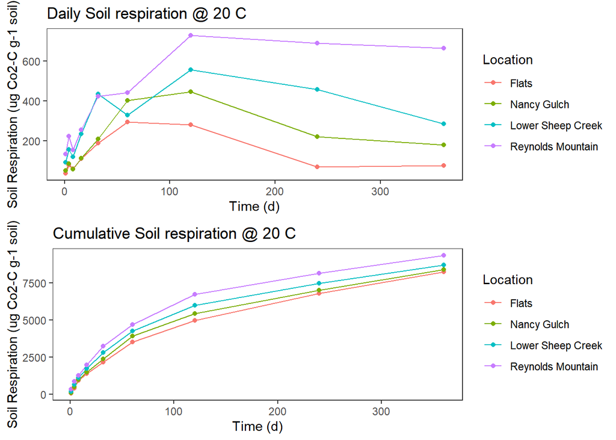

```r
soilCO2 <- as.data.frame(read_excel(paste0(data_path,"CO2 respiration.xlsx"), sheet = "data"))

#convert coordinates to decimal degrees
dd_coords_co2 <- as.data.frame(UTM_to_DD(soilCO2$X_Easting, soilCO2$Y_Northing))
soilCO2$lat <- dd_coords_co2$y
soilCO2$long <- dd_coords_co2$x

#rearrange the dataframe
soilCO2 <- soilCO2 %>% select(Day, SampleID, Location, Elevation,
                              X_Easting, Y_Northing, lat, long,
                              respC_gsoil_d_15C, respC_gsoil_d_20C, respC_gsoil_d_25C, respC_gsoil_d_30C)

#set plot order
soilCO2$Location <- factor(soilCO2$Location , levels=c("Flats", "Nancy Gulch", "Lower Sheep Creek", "Reynolds Mountain"))

##Respiration plot
soilCO2_daily_20C_avg <- soilCO2 %>% select(Day, Location, respC_gsoil_d_20C) %>% group_by(Day, Location) %>%
                          summarize(CO2_20C = mean(respC_gsoil_d_20C),
                                    CO2_20C_sterr = sd(respC_gsoil_d_20C)/sqrt(n()),
                                    n = n())

#plot daily respiration rates
CO2_20C_plot <- ggplot(soilCO2_daily_20C_avg, aes(x=Day, y=CO2_20C, color=Location)) + geom_line() + geom_point() +
  theme_bw() + theme(panel.grid.major = element_blank(), panel.grid.minor = element_blank()) +
  ggtitle("Daily Soil respiration @ 20 C") +
  xlab("Time (d)") +
  ylab("Soil Respiration (ug Co2-C g-1 soil)")

#plot cumulative respiration
soilCO2_daily_20C_avg$CO2_20C_sum <- cumsum(soilCO2_daily_20C_avg$CO2_20C)
CO2_20C_sum_plot <- ggplot(soilCO2_daily_20C_avg, aes(x=Day, y=CO2_20C_sum, color=Location)) + geom_line() + geom_point() +
  theme_bw() + theme(panel.grid.major = element_blank(), panel.grid.minor = element_blank()) +
  ggtitle("Cumulative Soil respiration @ 20 C") +
  xlab("Time (d)") +
  ylab("Soil Respiration (ug Co2-C g-1 soil)")

grid.arrange(CO2_20C_plot, CO2_20C_sum_plot, ncol=1)
```

##### **Note: CO2 by temp data exists for temps 15, 20, 25, 30 C. For purpose of quantifying Q10.**

### 3. Soil C fractions (by particale size)

**Each soil sample was fractionated to separate:**

**- CPOM: Coarse particulate organic matter (>250um)**

**- FPOM: fine particulate organic matter (53-250um)**

**- Clay (<52um)**

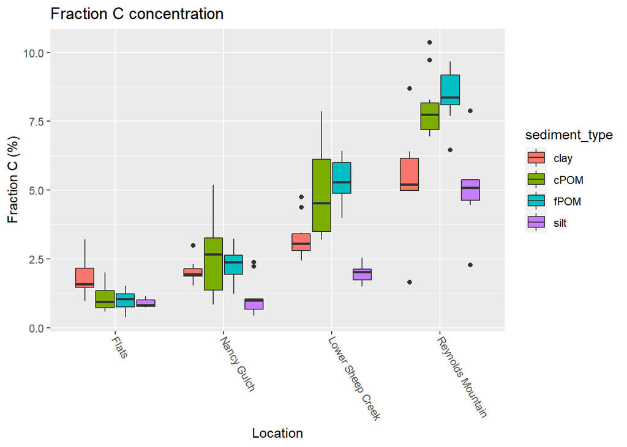

```r
fracs <- as.data.frame(read_excel(paste0(data_path,"fractions (0-5cm).xlsx"), sheet = "data"))

fracs[fracs == "no data" ] <- NA
names(fracs)[names(fracs) == 'C%'] <- 'Cperc'
names(fracs)[names(fracs) == 'Total Fraction.Weight (g)'] <- 'frac_mass'

# plot C%
fracs$Location <- factor(fracs$Location , levels=c("Flats", "Nancy Gulch", "Lower Sheep Creek", "Reynolds Mountain"))
fracs_Cby_loc <- ggplot(fracs, aes(x=Location, y=as.numeric(Cperc), fill=sediment_type)) + geom_boxplot() +
  xlab("Location") + ylab("Fraction C (%)") + ggtitle("Fraction C concentration") +
  theme(axis.text.x = element_text(angle = -60, vjust = 0.5, hjust=0))
fracs_Cby_loc
```

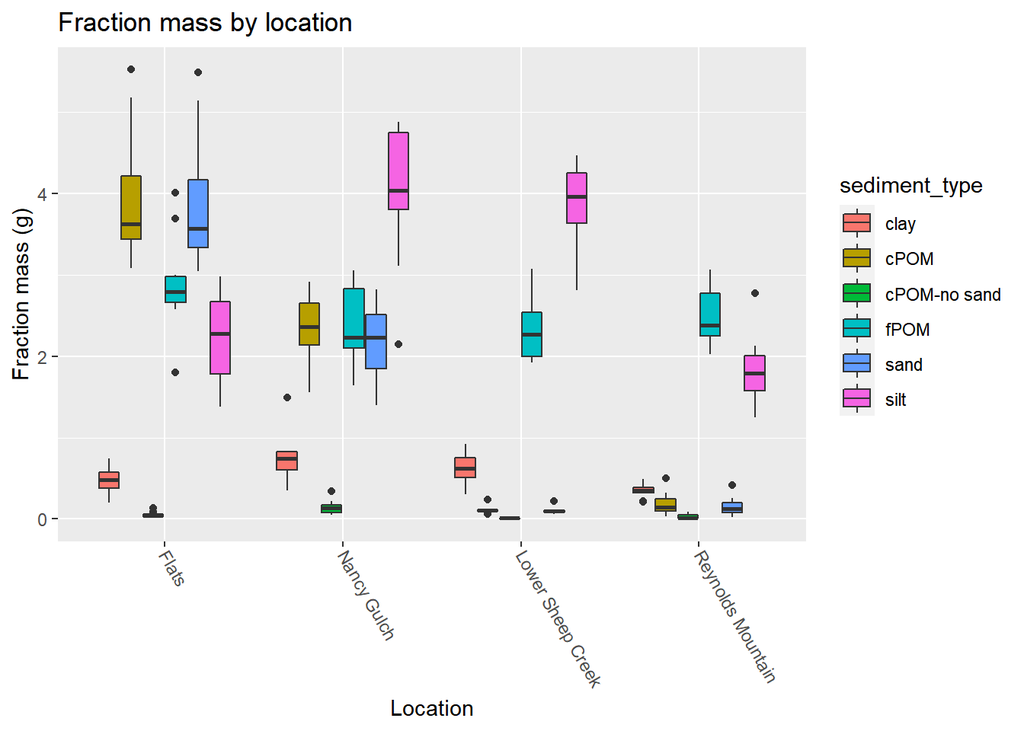

```r
#plot fraction mass by location
fracs_massby_loc <- ggplot(fracs, aes(x=Location, y=as.numeric(frac_mass), fill=sediment_type)) + geom_boxplot() +
  xlab("Location") + ylab("Fraction mass (g)") + ggtitle("Fraction mass by location") +
  theme(axis.text.x = element_text(angle = -60, vjust = 0.5, hjust=0))
fracs_massby_loc
```

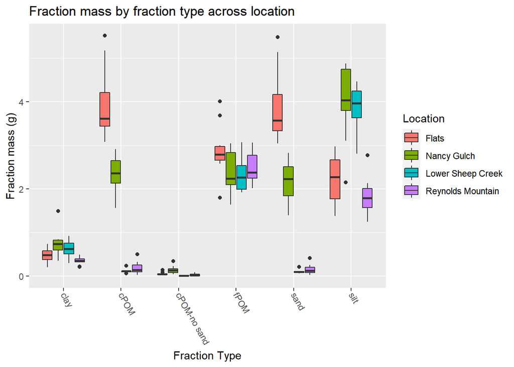

```r
#plot fraction mass by fraction type across location
fracs_massby_fracloc <- ggplot(fracs, aes(x=sediment_type, y=as.numeric(frac_mass), fill=Location)) + geom_boxplot() +
  xlab("Fraction Type") + ylab("Fraction mass (g)") + ggtitle("Fraction mass by fraction type across location") +
  theme(axis.text.x = element_text(angle = -60, vjust = 0.5, hjust=0))
fracs_massby_fracloc
```

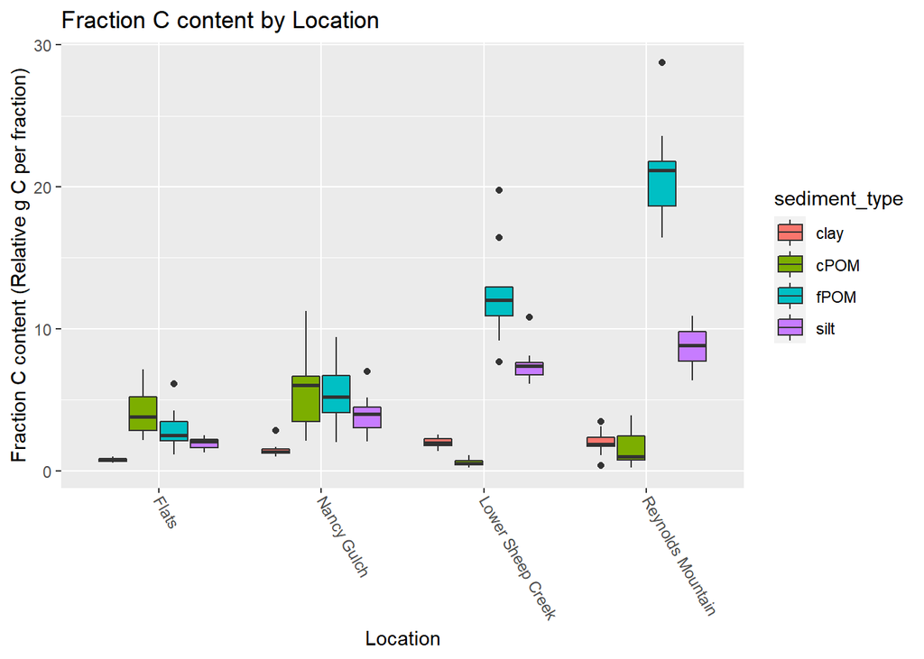

```r
#plot C content of the fractions
fracs$Ccontent <- as.numeric(fracs$frac_mass) * as.numeric(fracs$Cperc)
fracs_Cconby_loc <- ggplot(fracs, aes(x=Location, y=as.numeric(Ccontent), fill=sediment_type)) + geom_boxplot() +
  xlab("Location") + ylab("Fraction C content (Relative g C per fraction)") + ggtitle("Fraction C content by Location") +
  theme(axis.text.x = element_text(angle = -60, vjust = 0.5, hjust=0))
fracs_Cconby_loc
```

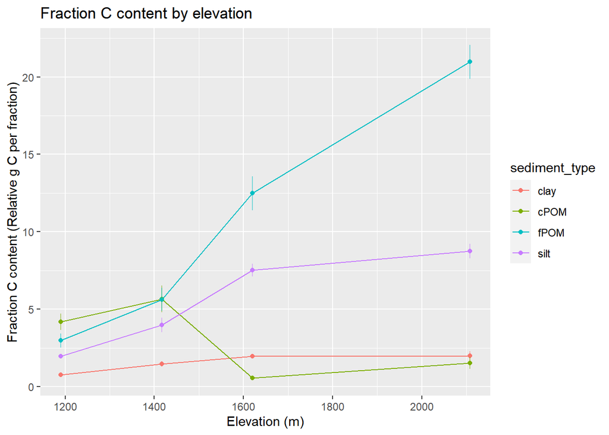

```r
#plot elevation trend in C per fractions
frac_sum <- fracs %>% select(Location, Elevation, sediment_type, Ccontent) %>% group_by(Location, sediment_type) %>%
              summarize(Ccon_avg = mean(Ccontent),
                        Ccon_se = sd(Ccontent)/sqrt(n()),
                        Elev_avg = round(mean(Elevation),0)) %>%
              na.omit()

fracs_Cconby_elev <- ggplot(frac_sum, aes(x=Elev_avg, y=Ccon_avg, color=sediment_type)) + geom_line() + geom_point() +
  geom_errorbar(aes(ymin=Ccon_avg-Ccon_se, ymax=Ccon_avg+Ccon_se), width=.2, alpha=0.5) +
  xlab("Elevation (m)") + ylab("Fraction C content (Relative g C per fraction)") + ggtitle("Fraction C content by elevation")
fracs_Cconby_elev
```

##### **How to interpret this data into POM vs MAOM pools?**

fPOM ==> POM pool

clay ==> MAOM pool

silt ==> ?

cPOM ==> Ignore?

### 4. Litter Stocks

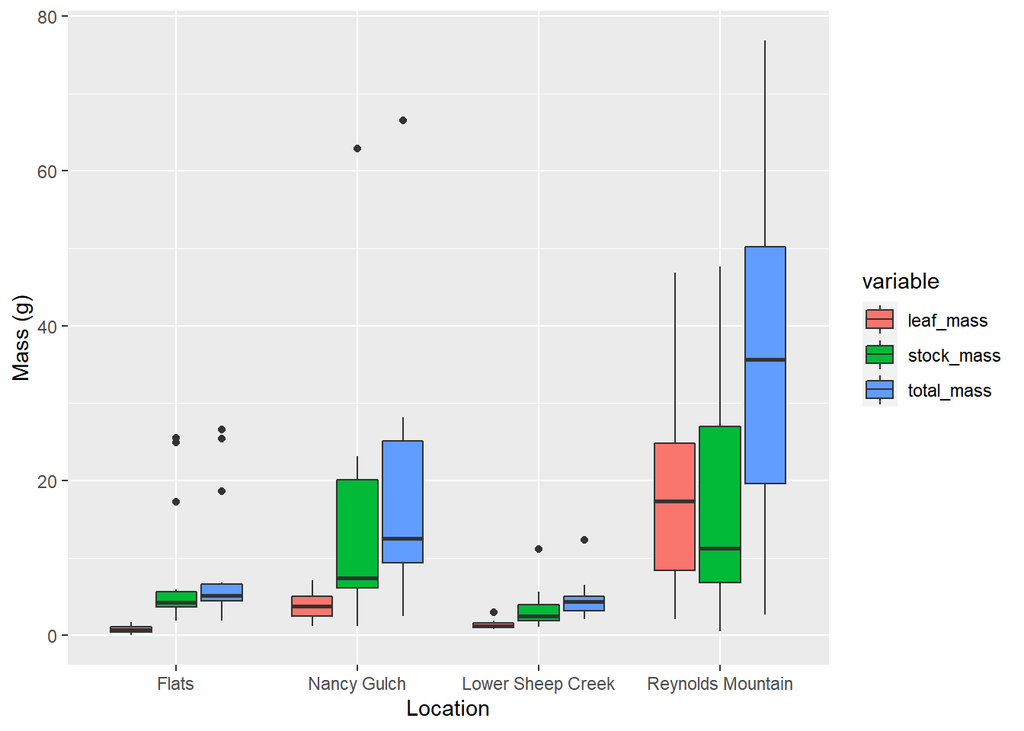

```r
litmass <-  as.data.frame(read_excel(paste0(data_path,"Leaf and Stalk Mass (2014).xlsx"), sheet = "data"))

names(litmass)[names(litmass) == 'Leaf Mass.Tot (g)'] <- 'leaf_mass'
names(litmass)[names(litmass) == 'Stalk Mass.Tot (g)'] <- 'stock_mass'
litmass$total_mass <- litmass$leaf_mass + litmass$stock_mass

#melt data to turn mass columns into rows
lit_mass_melt <- melt(litmass, id=c("Site", "Location", "X_Easting", "Y_Northing", "Elevation"))

#plot litter mass by type and location
lit_mass_melt$Location <- factor(lit_mass_melt$Location , levels=c("Flats", "Nancy Gulch", "Lower Sheep Creek", "Reynolds Mountain"))
ggplot(lit_mass_melt, aes(x=Location, y=value, fill=variable)) + geom_boxplot() +
  ylab("Mass (g)")
```

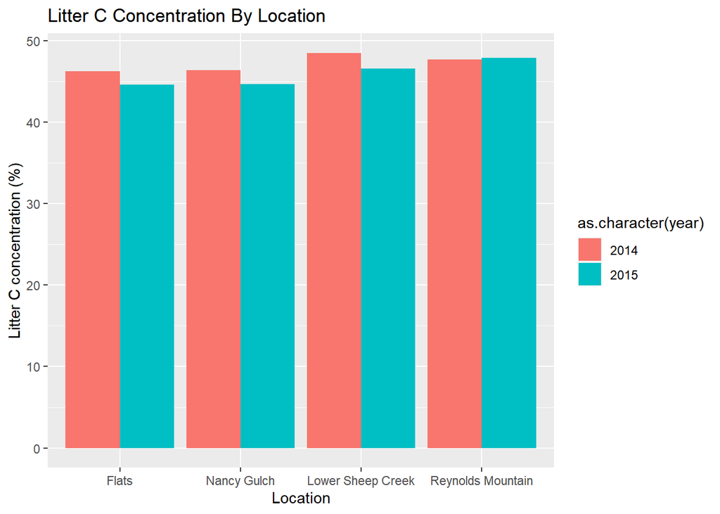

```r
litCN <-  as.data.frame(read_excel(paste0(data_path,"litter CN.xlsx"), sheet = "data"))

names(litCN)[names(litCN) == 'C%'] <- 'Cperc'
names(litCN)[names(litCN) == 'N%'] <- 'Nperc'

litCN$Location <- factor(litCN$Location , levels=c("Flats", "Nancy Gulch", "Lower Sheep Creek", "Reynolds Mountain"))

#plot C by location and year
ggplot(litCN, aes(x=Location, y=Cperc, group=year, fill=as.character(year))) +
  geom_bar(stat = "summary", fun = "mean", position = "dodge") +
  ylab("Litter C concentration (%)") + ggtitle("Litter C Concentration By Location")
```

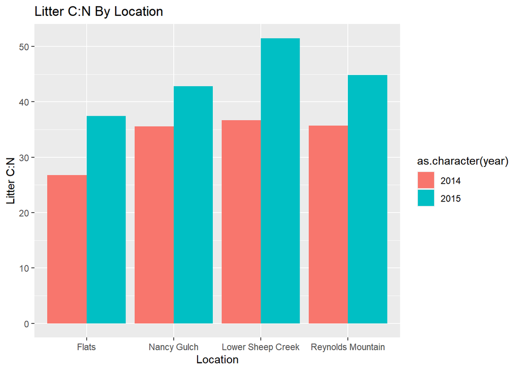

```r
#plot CN by location and year
ggplot(litCN, aes(x=Location, y=Cperc/Nperc, group=year, fill=as.character(year))) +
  geom_bar(stat = "summary", fun = "mean", position = "dodge") +
  ylab("Litter C:N") + ggtitle("Litter C:N By Location")
```

##### **Litterfall data take away…**

- Very little leaf litterfall inputs in the lower elevations.
- Not purely an elevation dominated relationship for litterfall mass. Ecosystem type dependence? (see Nancy vs. Lower Sheep)
- Lower C:N in the flats, otherwise negligeable across the 3 higher elevation sites.

### 5. Microbial Composition

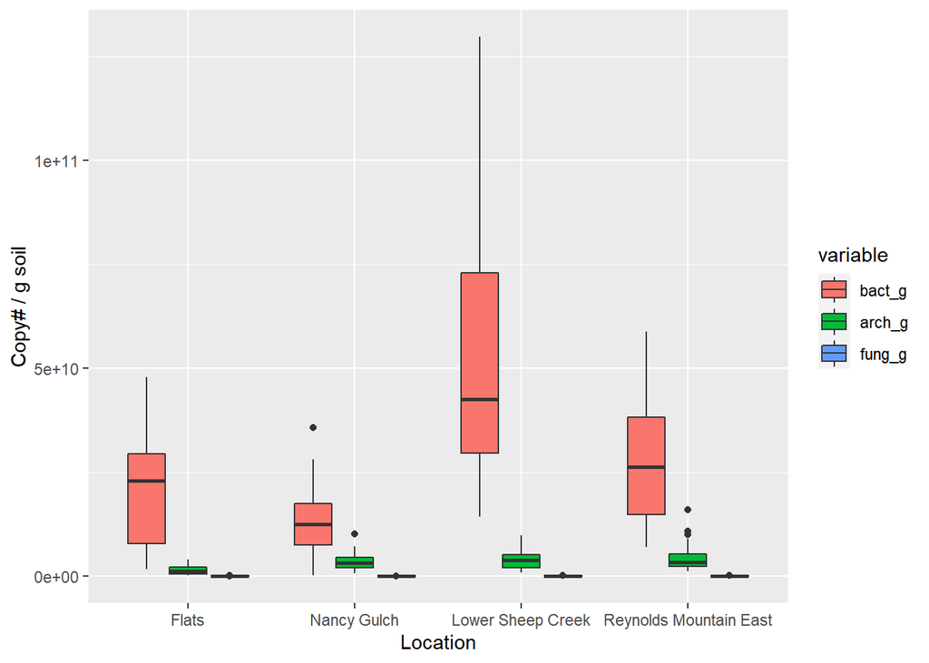

```r
mb <- as.data.frame(read_excel(paste0(data_path,"Microbial Composition.xlsx"), sheet = "data"))

names(mb)[names(mb) == 'total bacteria (copy#/gram soil)'] <- 'bact_g'
names(mb)[names(mb) == 'total archaeal (copy #/gram soil)'] <- 'arch_g'
names(mb)[names(mb) == 'total fungal (copy#/gram soil)'] <- 'fung_g'

#Prep data for plot
mb_melt <- mb %>% select(Location, bact_g, arch_g, fung_g) %>% melt("Location")

mb_melt$Location <- factor(mb_melt$Location , levels=c("Flats", "Nancy Gulch", "Lower Sheep Creek", "Reynolds Mountain East"))

#plot microbe data by location
ggplot(mb_melt, aes(x=Location, y=as.numeric(value), fill=variable)) + geom_boxplot() +
  ylab("Copy# / g soil")
```

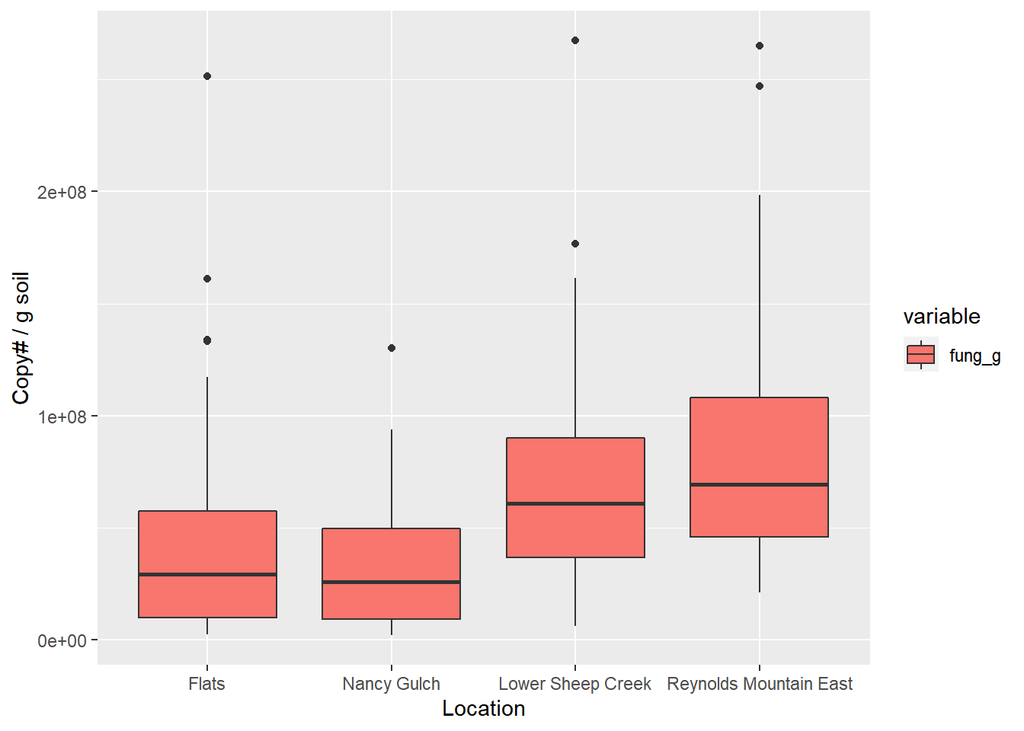

```r
#plot fungi alone
ggplot(mb_melt %>% filter(variable == "fung_g"), aes(x=Location, y=as.numeric(value), fill=variable)) + geom_boxplot() +
  ylab("Copy# / g soil")
```